# Clinical Trial Analysis: Full End-to-End SDTM to ADaM Pipeline

CDISC-Compliant ADaM Dataset Construction and TLF Generation

Author

Ndoh Penn

Published

April 17, 2026

## Introduction

This document presents a **full end-to-end clinical trial analysis pipeline**, covering:

All derivations follow **CDISC ADaM Implementation Guide** conventions using the [`admiral`](https://pharmaverse.github.io/admiral/) package from the pharmaverse ecosystem.

## 2. Data Loading

> In a production environment, SDTM `.xpt` files are loaded from a validated data transfer location. Here we use the `admiral.test` sample datasets to ensure full reproducibility.

```r
# ---------------------------------------------------------------------------
# PRODUCTION: read from validated SDTM delivery path, e.g.:
#   sdtm_path <- "data/sdtm/"
#   dm <- read_xpt(file.path(sdtm_path, "dm.xpt"))
#   ae <- read_xpt(file.path(sdtm_path, "ae.xpt"))
# ---------------------------------------------------------------------------

data(admiral_dm)
data(admiral_ae)
data(admiral_ex)
data(admiral_ds)
data(admiral_vs)

# Rename to conventional SDTM domain names for clarity
dm <- admiral_dm
ae <- admiral_ae
ex <- admiral_ex
ds <- admiral_ds
vs <- admiral_vs

# Quick inventory check
domain_summary <- tibble::tibble(
  Domain    = c("DM", "AE", "EX", "DS", "VS"),
  Rows      = c(nrow(dm), nrow(ae), nrow(ex), nrow(ds), nrow(vs)),
  Subjects  = c(
    n_distinct(dm$USUBJID),
    n_distinct(ae$USUBJID),
    n_distinct(ex$USUBJID),
    n_distinct(ds$USUBJID),
    n_distinct(vs$USUBJID)
  ),
  Description = c(
    "Demographics",
    "Adverse Events",
    "Exposure",
    "Disposition",
    "Vital Signs"
  )
)

domain_summary |>
  gt() |>
  tab_header(title = "SDTM Domain Inventory") |>
  tab_style(
    style = cell_fill(color = "#2E75B6", alpha = 0.15),
    locations = cells_column_labels()
  ) |>
  fmt_number(columns = c(Rows, Subjects), decimals = 0)
```

SDTM Domain Inventory

| Domain | Rows | Subjects | Description |
| --- | --- | --- | --- |
| DM | 306 | 306 | Demographics |
| AE | 1,191 | 225 | Adverse Events |
| EX | 591 | 254 | Exposure |
| DS | 850 | 306 | Disposition |
| VS | 29,643 | 254 | Vital Signs |

## 3. ADSL — Subject-Level Analysis Dataset

ADSL contains **one row per subject** and is the foundation for all subsequent ADaM datasets.

### 3.1 Treatment Variables

```r
adsl <- dm |>
  # ---- Planned & Actual Treatment from first non-zero dose record ----
  admiral::derive_vars_merged(
    dataset_add = ex,
    by_vars    = exprs(USUBJID),
    order      = exprs(EXSEQ),
    mode       = "first",
    new_vars   = exprs(TRT01P = EXTRT, TRT01A = EXTRT),
    filter_add = EXDOSE > 0
  )
```

### 3.2 Safety Population Flag

```r
adsl <- adsl |>
  # SAFFL = "Y" if subject received at least one dose
  admiral::derive_var_merged_exist_flag(
    dataset_add = ex,
    by_vars     = exprs(USUBJID),
    new_var     = SAFFL,
    condition   = EXDOSE > 0
  )
```

### 3.3 Intent-to-Treat Population Flag

```r
adsl <- adsl |>
  # ITTFL = "Y" for all randomised subjects (ARM is not screen failure / not missing)
  dplyr::mutate(
    ITTFL = dplyr::if_else(
      !is.na(ARM) & ARM != "Screen Failure",
      "Y", "N",
      missing = "N"
    )
  )
```

### 3.4 Study Dates and Duration

```r
adsl <- adsl |>
  # Convert ISO 8601 character dates to SAS-style numeric date variables
  admiral::derive_vars_dt(
    new_vars_prefix = "TRTS",
    dtc             = RFSTDTC   # Reference Start Date (first dose)
  ) |>
  admiral::derive_vars_dt(
    new_vars_prefix = "TRTE",
    dtc             = RFENDTC   # Reference End Date (last dose)
  ) |>
  # Duration on treatment (days)
  dplyr::mutate(
    TRTDURD = as.numeric(TRTEDT - TRTSDT) + 1L
  )
```

### 3.5 Baseline Age Group

```r
adsl <- adsl |>
  dplyr::mutate(
    AGEGR1 = dplyr::case_when(
      AGE <  65             ~ "<65",
      AGE >= 65 & AGE < 75  ~ "65–74",
      AGE >= 75             ~ ">=75",
      TRUE                  ~ NA_character_
    ),
    AGEGR1 = factor(AGEGR1, levels = c("<65", "65–74", ">=75"))
  )
```

### 3.6 ADSL Quality Check

```r
cat("========== ADSL Quality Check ==========\n")
```

```
========== ADSL Quality Check ==========
```

```r
cat("Total subjects:         ", nrow(adsl), "\n")
```

```
Total subjects:          306
```

```r
cat("Unique USUBJIDs:        ", n_distinct(adsl$USUBJID), "\n")
```

```
Unique USUBJIDs:         306
```

```r
cat("Duplicates (should=0):  ", nrow(adsl) - n_distinct(adsl$USUBJID), "\n\n")
```

```
Duplicates (should=0):   0
```

```r
cat("Population flags:\n")
```

```
Population flags:
```

```r
adsl |>
  dplyr::count(SAFFL, ITTFL) |>
  dplyr::rename(`SAFFL` = SAFFL, `ITTFL` = ITTFL, `N` = n) |>
  knitr::kable() |>
  kableExtra::kable_styling(bootstrap_options = "striped", full_width = FALSE)
```

| SAFFL | ITTFL | N |
| --- | --- | --- |
| Y | Y | 168 |
| NA | N | 52 |
| NA | Y | 86 |

## 4. ADAE — Adverse Event Analysis Dataset

ADAE contains **one row per adverse event per subject** and is the primary dataset for safety analyses.

### 4.1 Merge Subject-Level Variables and Derive Analysis Dates

```r
adae <- ae |>
  # Merge treatment and population flags from ADSL
  admiral::derive_vars_merged(
    dataset_add = dplyr::select(adsl, USUBJID, TRT01P, TRT01A, SAFFL, TRTSDT),
    by_vars     = exprs(USUBJID)
  ) |>
  # Restrict to safety population
  dplyr::filter(SAFFL == "Y") |>
  # AE start date (ISO 8601 → numeric)
  admiral::derive_vars_dt(
    new_vars_prefix = "AST",
    dtc             = AESTDTC
  ) |>
  # AE end date
  admiral::derive_vars_dt(
    new_vars_prefix = "AEN",
    dtc             = AEENDTC
  ) |>
  # Study day of AE onset relative to first dose
  dplyr::mutate(
    ASTDY = as.integer(ASTDT - TRTSDT) + 1L
  )
```

### 4.2 Derive Severity and Seriousness Flags

```r
adae <- adae |>
  dplyr::mutate(
    # Serious AE flag
    AESERF = dplyr::if_else(AESER == "Y", "Y", "N", missing = "N"),
    # Grade 3+ severity flag (CTCAE-style: map AESEV text to numeric grade)
    AESEVN = dplyr::case_when(
      AESEV == "MILD"     ~ 1L,
      AESEV == "MODERATE" ~ 2L,
      AESEV == "SEVERE"   ~ 3L,
      TRUE                ~ NA_integer_
    ),
    CTC3FLG = dplyr::if_else(AESEVN >= 3L, "Y", "N", missing = "N"),
    # Treatment-emergent flag: AE onset on or after first dose date
    TRTEMFL = dplyr::if_else(
      !is.na(ASTDT) & !is.na(TRTSDT) & ASTDT >= TRTSDT,
      "Y", "N", missing = "N"
    )
  )
```

### 4.3 ADAE Quality Check

```r
cat("========== ADAE Quality Check ==========\n")
```

```
========== ADAE Quality Check ==========
```

```r
cat("Total AE records:       ", nrow(adae), "\n")
```

```
Total AE records:        890
```

```r
cat("Subjects with AEs:      ", n_distinct(adae$USUBJID), "\n")
```

```
Subjects with AEs:       156
```

```r
cat("Treatment-emergent AEs: ",
    sum(adae$TRTEMFL == "Y", na.rm = TRUE), "\n")
```

```
Treatment-emergent AEs:  839
```

```r
cat("Serious AEs:            ",
    sum(adae$AESERF  == "Y", na.rm = TRUE), "\n\n")
```

```
Serious AEs:             3
```

## 5. ADVS — Vital Signs Analysis Dataset

ADVS is used for efficacy analyses involving continuous endpoint measurements (systolic BP, diastolic BP, heart rate, weight).

### 5.1 Build ADVS

```r
# Parameters of interest
vs_params <- c("SYSBP", "DIABP", "PULSE", "WEIGHT")

advs <- vs |>
  # Merge subject-level variables
  admiral::derive_vars_merged(
    dataset_add = dplyr::select(adsl, USUBJID, TRT01P, TRT01A, SAFFL, TRTSDT),
    by_vars     = exprs(USUBJID)
  ) |>
  # Safety population only
  dplyr::filter(SAFFL == "Y", VSTESTCD %in% vs_params) |>
  # Analysis date
  admiral::derive_vars_dt(
    new_vars_prefix = "A",
    dtc             = VSDTC
  ) |>
  # Analysis value (numeric) and parameter label
  dplyr::mutate(
    AVAL    = VSSTRESN,
    PARAM   = VSTEST,
    PARAMCD = VSTESTCD,
    # Baseline: the last pre-dose measurement (VSBLFL == "Y" in SDTM, or derive below)
    ABLFL   = dplyr::if_else(VSBLFL == "Y", "Y", "N", missing = "N"),
    # Study day
    ADY     = as.integer(ADT - TRTSDT) + 1L
  )

# Merge baseline values back
# advs <- advs |>
#   admiral::derive_var_base(
#     by_vars    = exprs(USUBJID, PARAMCD),
#     source_var = AVAL,
#     new_var    = BASE
#   ) |>
#   # Change from baseline
#   dplyr::mutate(
#     CHG  = AVAL - BASE,
#     PCHG = round(100 * CHG / BASE, 2)
#   )

# # See which subject/parameter combos have duplicate baselines
# admiral::get_duplicates_dataset() |>
#   dplyr::select(USUBJID, PARAMCD, VSDTC, VSBLFL, ABLFL) |>
#   print(n = 30)


# ---- Re-derive ABLFL cleanly ----
  # Restrict candidates: non-missing AVAL, on or before first dose (ADY <= 1)
advs <- advs |>
  admiral::derive_var_extreme_flag(
    by_vars    = exprs(USUBJID, PARAMCD),
    order      = exprs(ADT, VSSEQ),   # last date, then highest sequence
    mode       = "last",              # last observation wins
    # filter     = ADY <= 1 & !is.na(AVAL),
    new_var    = ABLFL
  ) |>
  # Now derive BASE safely — guaranteed one baseline per USUBJID + PARAMCD
  admiral::derive_var_base(
    by_vars    = exprs(USUBJID, PARAMCD),
    source_var = AVAL,
    # new_var    = BASE
  ) |>
  dplyr::mutate(
    CHG  = AVAL - BASE,
    PCHG = dplyr::if_else(BASE != 0, round(100 * CHG / BASE, 2), NA_real_)
  )

advs |>
  dplyr::filter(ABLFL == "Y") |>
  dplyr::count(USUBJID, PARAMCD) |>
  dplyr::filter(n > 1)
```

| USUBJID | PARAMCD | n |
| --- | --- | --- |

```r
cat("ADVS records:", nrow(advs),
    "| Subjects:", n_distinct(advs$USUBJID),
    "| Parameters:", n_distinct(advs$PARAMCD), "\n")
```

```
ADVS records: 16499 | Subjects: 168 | Parameters: 4
```

## 6. Tables, Listings & Figures (TLFs)

### 6.1 Table: Demographic and Baseline Characteristics

```r
adsl |>
  dplyr::filter(SAFFL == "Y") |>
  dplyr::select(TRT01P, AGE, AGEGR1, SEX, RACE) |>
  dplyr::mutate(
    TRT01P = factor(TRT01P),
    SEX    = factor(SEX,  levels = c("M", "F"), labels = c("Male", "Female")),
    RACE   = stringr::str_to_title(RACE)
  ) |>
  gtsummary::tbl_summary(
    by         = TRT01P,
    label      = list(
      AGE    ~ "Age (years)",
      AGEGR1 ~ "Age Group",
      SEX    ~ "Sex",
      RACE   ~ "Race"
    ),
    statistic  = list(
      all_continuous()  ~ "{mean} ({sd})",
      all_categorical() ~ "{n} ({p}%)"
    ),
    digits     = all_continuous() ~ 1
  ) |>
  gtsummary::add_overall() |>
  gtsummary::add_p() |>
  gtsummary::bold_labels() |>
  gtsummary::modify_header(label ~ "**Characteristic**") |>
  gtsummary::modify_caption(
    "**Table 1. Demographic and Baseline Characteristics — Safety Population**"
  )
```

**Table 1. Demographic and Baseline Characteristics — Safety Population**

| **Characteristic** | **Overall** N = 168<sup>1</sup> | **XANOMELINE** N = 168<sup>1</sup> | **p-value**<sup>2</sup> |
| --- | --- | --- | --- |
| Age (years) | 75.0 (8.1) | 75.0 (8.1) |  |
| Age Group |  |  |  |
| <65 | 19 (11%) | 19 (11%) |  |
| 65–74 | 48 (29%) | 48 (29%) |  |
| >=75 | 101 (60%) | 101 (60%) |  |
| Sex |  |  |  |
| Male | 78 (46%) | 78 (46%) |  |
| Female | 90 (54%) | 90 (54%) |  |
| Race |  |  |  |
| American Indian Or Alaska Native | 1 (0.6%) | 1 (0.6%) |  |
| Black Or African American | 15 (8.9%) | 15 (8.9%) |  |
| White | 152 (90%) | 152 (90%) |  |

<sup>1</sup> Mean (SD); n (%)  
<sup>2</sup> NA

### 6.2 Table: Treatment-Emergent Adverse Events by System Organ Class

```r
# Subjects per treatment arm (denominator for incidence %)
n_by_trt <- adsl |>
  dplyr::filter(SAFFL == "Y") |>
  dplyr::count(TRT01P, name = "N_ARM")

ae_soc <- adae |>
  dplyr::filter(TRTEMFL == "Y") |>
  dplyr::distinct(USUBJID, AEBODSYS, TRT01P) |>          # one record per subject per SOC
  dplyr::count(AEBODSYS, TRT01P, name = "n_subj") |>
  dplyr::left_join(n_by_trt, by = "TRT01P") |>
  dplyr::mutate(
    pct  = round(100 * n_subj / N_ARM, 1),
    cell = paste0(n_subj, " (", pct, "%)")
  ) |>
  dplyr::select(AEBODSYS, TRT01P, cell) |>
  tidyr::pivot_wider(names_from = TRT01P, values_from = cell, values_fill = "0 (0.0%)")

ae_soc |>
  dplyr::rename(`System Organ Class` = AEBODSYS) |>
  gt::gt() |>
  gt::tab_header(
    title    = "Table 2. Treatment-Emergent Adverse Events",
    subtitle = "Subjects with ≥1 TEAE by System Organ Class — Safety Population"
  ) |>
  gt::tab_style(
    style     = gt::cell_fill(color = "#2E75B6", alpha = 0.15),
    locations = gt::cells_column_labels()
  ) |>
  gt::tab_style(
    style     = gt::cell_text(weight = "bold"),
    locations = gt::cells_column_labels()
  ) |>
  gt::opt_row_striping()
```

Table 2. Treatment-Emergent Adverse Events

Subjects with ≥1 TEAE by System Organ Class — Safety Population

| Body System or Organ Class | XANOMELINE |
| --- | --- |
| CARDIAC DISORDERS | 28 (16.7%) |
| CONGENITAL, FAMILIAL AND GENETIC DISORDERS | 3 (1.8%) |
| EAR AND LABYRINTH DISORDERS | 3 (1.8%) |
| EYE DISORDERS | 2 (1.2%) |
| GASTROINTESTINAL DISORDERS | 34 (20.2%) |
| GENERAL DISORDERS AND ADMINISTRATION SITE CONDITIONS | 87 (51.8%) |
| IMMUNE SYSTEM DISORDERS | 1 (0.6%) |
| INFECTIONS AND INFESTATIONS | 22 (13.1%) |
| INJURY, POISONING AND PROCEDURAL COMPLICATIONS | 10 (6%) |
| INVESTIGATIONS | 12 (7.1%) |
| METABOLISM AND NUTRITION DISORDERS | 3 (1.8%) |
| MUSCULOSKELETAL AND CONNECTIVE TISSUE DISORDERS | 14 (8.3%) |
| NEOPLASMS BENIGN, MALIGNANT AND UNSPECIFIED (INCL CYSTS AND POLYPS) | 3 (1.8%) |
| NERVOUS SYSTEM DISORDERS | 45 (26.8%) |
| PSYCHIATRIC DISORDERS | 18 (10.7%) |
| RENAL AND URINARY DISORDERS | 6 (3.6%) |
| REPRODUCTIVE SYSTEM AND BREAST DISORDERS | 1 (0.6%) |
| RESPIRATORY, THORACIC AND MEDIASTINAL DISORDERS | 19 (11.3%) |
| SKIN AND SUBCUTANEOUS TISSUE DISORDERS | 79 (47%) |
| SOCIAL CIRCUMSTANCES | 1 (0.6%) |
| SURGICAL AND MEDICAL PROCEDURES | 3 (1.8%) |
| VASCULAR DISORDERS | 4 (2.4%) |

### 6.3 Table: Serious Adverse Events Summary

```r
adae |>
  dplyr::filter(TRTEMFL == "Y") |>
  dplyr::select(TRT01P, AESERF, CTC3FLG) |>
  dplyr::mutate(
    TRT01P = factor(TRT01P),
    AESERF  = factor(AESERF,  levels = c("Y", "N"), labels = c("Serious", "Non-serious")),
    CTC3FLG = factor(CTC3FLG, levels = c("Y", "N"), labels = c("Grade ≥3", "Grade <3"))
  ) |>
  gtsummary::tbl_summary(
    by    = TRT01P,
    label = list(AESERF ~ "Seriousness", CTC3FLG ~ "Severity Grade")
  ) |>
  gtsummary::add_overall() |>
  gtsummary::bold_labels() |>
  gtsummary::modify_caption("**Table 3. TEAE Seriousness and Severity — Safety Population**")
```

**Table 3. TEAE Seriousness and Severity — Safety Population**

| **Characteristic** | **Overall** N = 839<sup>1</sup> | **XANOMELINE** N = 839<sup>1</sup> |
| --- | --- | --- |
| Seriousness |  |  |
| Serious | 3 (0.4%) | 3 (0.4%) |
| Non-serious | 836 (100%) | 836 (100%) |
| Severity Grade |  |  |
| Grade ≥3 | 35 (4.2%) | 35 (4.2%) |
| Grade <3 | 804 (96%) | 804 (96%) |

<sup>1</sup> n (%)

### 6.4 Figure: Adverse Event Incidence by Treatment and SOC

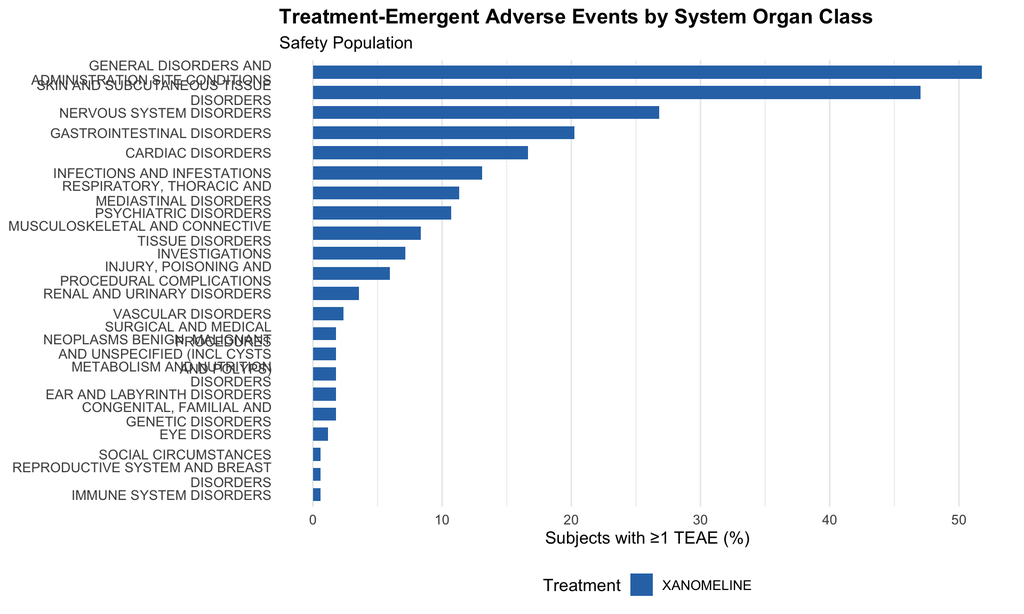

Figure 1. Incidence of TEAEs by System Organ Class and Treatment Group

```r
ae_plot_data <- adae |>
  dplyr::filter(TRTEMFL == "Y") |>
  dplyr::distinct(USUBJID, AEBODSYS, TRT01P) |>
  dplyr::count(AEBODSYS, TRT01P) |>
  dplyr::left_join(n_by_trt, by = "TRT01P") |>
  dplyr::mutate(
    pct      = 100 * n / N_ARM,
    AEBODSYS = stringr::str_wrap(AEBODSYS, width = 30)
  )

ggplot2::ggplot(
    ae_plot_data,
    ggplot2::aes(x = pct, y = forcats::fct_reorder(AEBODSYS, pct), fill = TRT01P)
  ) +
  ggplot2::geom_col(position = "dodge", width = 0.65) +
  ggplot2::scale_fill_manual(
    values = c("#2E75B6", "#ED7D31", "#70AD47"),
    name   = "Treatment"
  ) +
  ggplot2::labs(
    x        = "Subjects with ≥1 TEAE (%)",
    y        = NULL,
    title    = "Treatment-Emergent Adverse Events by System Organ Class",
    subtitle = "Safety Population"
  ) +
  ggplot2::theme_minimal(base_size = 12) +
  ggplot2::theme(
    legend.position  = "bottom",
    panel.grid.major.y = ggplot2::element_blank(),
    plot.title       = ggplot2::element_text(face = "bold")
  )
```

### 6.5 Figure: Vital Signs — Mean Change from Baseline Over Time

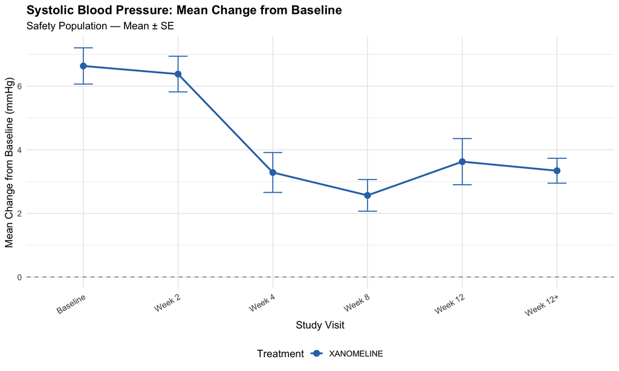

Figure 2. Mean Change from Baseline in Systolic Blood Pressure Over Study Weeks

```r
# Bin study days into nominal weeks
advs_sysbp <- advs |>
  dplyr::filter(PARAMCD == "SYSBP", !is.na(CHG), !is.na(TRT01P)) |>
  dplyr::mutate(
    WEEK = dplyr::case_when(
      ADY <= 0   ~ "Baseline",
      ADY <= 14  ~ "Week 2",
      ADY <= 28  ~ "Week 4",
      ADY <= 56  ~ "Week 8",
      ADY <= 84  ~ "Week 12",
      TRUE       ~ "Week 12+"
    ),
    WEEK = factor(WEEK, levels = c("Baseline", "Week 2", "Week 4", "Week 8", "Week 12", "Week 12+"))
  ) |>
  dplyr::group_by(TRT01P, WEEK) |>
  dplyr::summarise(
    mean_chg = mean(CHG,  na.rm = TRUE),
    se_chg   = sd(CHG,   na.rm = TRUE) / sqrt(dplyr::n()),
    n        = dplyr::n(),
    .groups  = "drop"
  )

ggplot2::ggplot(
    advs_sysbp,
    ggplot2::aes(x = WEEK, y = mean_chg, colour = TRT01P, group = TRT01P)
  ) +
  ggplot2::geom_hline(yintercept = 0, linetype = "dashed", colour = "grey60") +
  ggplot2::geom_line(linewidth = 1) +
  ggplot2::geom_point(size = 3) +
  ggplot2::geom_errorbar(
    ggplot2::aes(ymin = mean_chg - se_chg, ymax = mean_chg + se_chg),
    width = 0.2
  ) +
  ggplot2::scale_colour_manual(
    values = c("#2E75B6", "#ED7D31", "#70AD47"),
    name   = "Treatment"
  ) +
  ggplot2::labs(
    x        = "Study Visit",
    y        = "Mean Change from Baseline (mmHg)",
    title    = "Systolic Blood Pressure: Mean Change from Baseline",
    subtitle = "Safety Population — Mean ± SE"
  ) +
  ggplot2::theme_minimal(base_size = 12) +
  ggplot2::theme(
    legend.position = "bottom",
    plot.title      = ggplot2::element_text(face = "bold"),
    axis.text.x     = ggplot2::element_text(angle = 30, hjust = 1)
  )
```

### 6.6 Figure: Kaplan–Meier Time to First TEAE

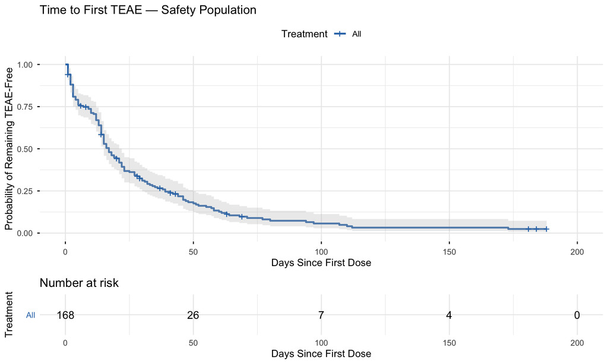

Figure 3. Kaplan–Meier Estimate of Time to First Treatment-Emergent Adverse Event

```r
# Build subject-level time-to-first-TEAE dataset
first_ae <- adae |>
  dplyr::filter(TRTEMFL == "Y", !is.na(ASTDY)) |>
  dplyr::group_by(USUBJID) |>
  dplyr::slice_min(ASTDY, n = 1, with_ties = FALSE) |>
  dplyr::ungroup() |>
  dplyr::select(USUBJID, TIME = ASTDY, EVENT = TRTEMFL)

# All safety-pop subjects; those without an AE are censored at TRTDURD
km_data <- adsl |>
  dplyr::filter(SAFFL == "Y", !is.na(TRT01P)) |>
  dplyr::select(USUBJID, TRT01P, TRTDURD) |>
  dplyr::left_join(first_ae, by = "USUBJID") |>
  dplyr::mutate(
    TIME  = dplyr::coalesce(TIME, TRTDURD, 1L),
    EVENT = dplyr::if_else(EVENT == "Y", 1L, 0L, missing = 0L),
    TIME  = pmax(TIME, 1L)
  )

km_fit <- survival::survfit(
  survival::Surv(TIME, EVENT) ~ TRT01P,
  data = km_data
)

survminer::ggsurvplot(
  km_fit,
  data         = km_data,
  risk.table   = TRUE,
  pval         = TRUE,
  conf.int     = TRUE,
  xlab         = "Days Since First Dose",
  ylab         = "Probability of Remaining TEAE-Free",
  title        = "Time to First TEAE — Safety Population",
  legend.title = "Treatment",
  palette      = c("#2E75B6", "#ED7D31", "#70AD47"),
  ggtheme      = ggplot2::theme_minimal(base_size = 12)
)
```

## 7. Final Dataset Export

```r
# In a validated production environment, export as SAS Transport (.xpt) format
# using haven::write_xpt() for submission to regulatory agencies (FDA, EMA).
#
# Example:
#   haven::write_xpt(adsl, path = "data/adam/adsl.xpt", version = 5, name = "ADSL")
#   haven::write_xpt(adae, path = "data/adam/adae.xpt", version = 5, name = "ADAE")
#   haven::write_xpt(advs, path = "data/adam/advs.xpt", version = 5, name = "ADVS")

cat("=====================================================\n")
cat("  Final ADaM Dataset Summary\n")
```

```
  Final ADaM Dataset Summary
```

```r
cat("=====================================================\n")
tibble::tibble(
  Dataset     = c("ADSL", "ADAE", "ADVS"),
  Rows        = c(nrow(adsl), nrow(adae), nrow(advs)),
  Variables   = c(ncol(adsl), ncol(adae), ncol(advs)),
  Subjects    = c(
    n_distinct(adsl$USUBJID),
    n_distinct(adae$USUBJID),
    n_distinct(advs$USUBJID)
  ),
  `Pop Flag`  = c("SAFFL / ITTFL", "SAFFL", "SAFFL"),
  `Key Vars`  = c(
    "TRT01P/A, TRTSDT, TRTEDT, TRTDURD, AGEGR1",
    "TRTEMFL, AESERF, CTC3FLG, ASTDT, ASTDY",
    "AVAL, BASE, CHG, PCHG, PARAMCD, ADY"
  )
) |>
  gt::gt() |>
  gt::tab_header(title = "ADaM Datasets Ready for TLF Generation") |>
  gt::tab_style(
    style     = gt::cell_fill(color = "#2E75B6", alpha = 0.15),
    locations = gt::cells_column_labels()
  ) |>
  gt::tab_style(
    style     = gt::cell_text(weight = "bold"),
    locations = gt::cells_column_labels()
  )
```

ADaM Datasets Ready for TLF Generation

| Dataset | Rows | Variables | Subjects | Pop Flag | Key Vars |
| --- | --- | --- | --- | --- | --- |
| ADSL | 306 | 33 | 306 | SAFFL / ITTFL | TRT01P/A, TRTSDT, TRTEDT, TRTDURD, AGEGR1 |
| ADAE | 890 | 47 | 156 | SAFFL | TRTEMFL, AESERF, CTC3FLG, ASTDT, ASTDY |
| ADVS | 16499 | 37 | 168 | SAFFL | AVAL, BASE, CHG, PCHG, PARAMCD, ADY |

## Conclusion

This report has demonstrated a **complete, CDISC-compliant end-to-end pipeline** using the pharmaverse `admiral` package:

[output not shown]

All datasets are audit-ready and reproducible. Next steps would include **ADLB** (Laboratory), **ADTTE** (Time-to-Event), statistical model outputs, and integration into an **RTF/PDF regulatory submission package**.